# Final

2023-04-16

# Summary

The data set is data on breast cancer patients and various aspects of their breast cell nuclei.It was originally collected by the University of California Irvine(UCI). It was made available/donated/collected on 11/01/1995.  
The data set contains 32 columns but these columns hold various summary stats(Specifically the mean, standard error, & worst) of the 10 measurements:

- Radius
- Texture
- Perimeter
- Area
- Smoothness
- Compactness
- Concavity
- Concave Points
- Symmetry
- Fractal Dimension

There are 569 entries in the data set.There are no null values.  
ID is an int value but can be ignored. The diagnosis tab is our target value and it contains two char values: M & B(M is short for malignant, B short for benign). All other tabs are num values which are the mean, standard error, and worst values of the terms of the list above. We will separate the mean,standard error, & worst values into their own data frames(We will focus on the mean first but want to keep the std or worst/bottoms of the distribution in case we need it later).

- Null: There is NO relationship between the size characteristics of a tumor and it’s concavity points
- Alt: There IS relationship between the size characteristics of a tumor and it’s concavity points

# Data Sample

Below I quickly take a look at the dataset. I show the first five rows of the dataset, as well as the types of each column, and what the two chars in the diagnosis column are.

```r
bc = read.csv("C:/Users/Benny/Downloads/BreastCancer.csv")
library(addAlpha)
library(corrplot, quietly = TRUE)
library(car, quietly = TRUE)
library(ltm)
library(RColorBrewer)

colors <- c("#6D7696", "#CC5543", "#FFB4BC", "#ba7da0", "#EDB579", "#DBE6AF", "#6D76B9", "#594810")
colorsT <- add.alpha(colors)
```

```r
corrCol <- brewer.pal(8, "RdPu")
```

```r
head(bc,5)
```

```
##         id diagnosis radius_mean texture_mean perimeter_mean area_mean
## 1   842302         M       17.99        10.38         122.80    1001.0
## 2   842517         M       20.57        17.77         132.90    1326.0
## 3 84300903         M       19.69        21.25         130.00    1203.0
## 4 84348301         M       11.42        20.38          77.58     386.1
## 5 84358402         M       20.29        14.34         135.10    1297.0
##   smoothness_mean compactness_mean concavity_mean concave.points_mean
## 1         0.11840          0.27760         0.3001             0.14710
## 2         0.08474          0.07864         0.0869             0.07017
## 3         0.10960          0.15990         0.1974             0.12790
## 4         0.14250          0.28390         0.2414             0.10520
## 5         0.10030          0.13280         0.1980             0.10430
##   symmetry_mean fractal_dimension_mean radius_se texture_se perimeter_se
## 1        0.2419                0.07871    1.0950     0.9053        8.589
## 2        0.1812                0.05667    0.5435     0.7339        3.398
```

[output cut: 27 more lines]

```r
str(bc)
```

```
## 'data.frame':    569 obs. of  32 variables:
##  $ id                     : int  842302 842517 84300903 84348301 84358402 843786 844359 84458202 844981 84501001 ...
##  $ diagnosis              : chr  "M" "M" "M" "M" ...
##  $ radius_mean            : num  18 20.6 19.7 11.4 20.3 ...
##  $ texture_mean           : num  10.4 17.8 21.2 20.4 14.3 ...
##  $ perimeter_mean         : num  122.8 132.9 130 77.6 135.1 ...
##  $ area_mean              : num  1001 1326 1203 386 1297 ...
##  $ smoothness_mean        : num  0.1184 0.0847 0.1096 0.1425 0.1003 ...
##  $ compactness_mean       : num  0.2776 0.0786 0.1599 0.2839 0.1328 ...
##  $ concavity_mean         : num  0.3001 0.0869 0.1974 0.2414 0.198 ...
##  $ concave.points_mean    : num  0.1471 0.0702 0.1279 0.1052 0.1043 ...
##  $ symmetry_mean          : num  0.242 0.181 0.207 0.26 0.181 ...
##  $ fractal_dimension_mean : num  0.0787 0.0567 0.06 0.0974 0.0588 ...
##  $ radius_se              : num  1.095 0.543 0.746 0.496 0.757 ...
##  $ texture_se             : num  0.905 0.734 0.787 1.156 0.781 ...
```

[output cut: 18 more lines]

```r
unique(bc$diagnosis)
```

```
## [1] "M" "B"
```

# Data Wrangling

In the following code block we separate the data into more manageable objects.

1. We change the diagnosis column to binary for easier use later. Malignant = 1 & Benign = 0.
2. We separate the dataset into three respective dataframes based on the stats collected for.

```r
#This code is to make 0s & 1s of the diagnosis col to allow for use in models
bc$diagnosis <- ifelse(bc$diagnosis == "M", 1, 0)

#This is the code that separates the data frame into their own based on the stats collected
mean_bc = subset(bc, select = c(diagnosis,radius_mean:fractal_dimension_mean))
std_bc = subset(bc, select = c(diagnosis,radius_se:fractal_dimension_se))
worst_bc = subset(bc, select = c(diagnosis,radius_worst:fractal_dimension_worst))

str(mean_bc)
```

```
## 'data.frame':    569 obs. of  11 variables:
##  $ diagnosis             : num  1 1 1 1 1 1 1 1 1 1 ...
##  $ radius_mean           : num  18 20.6 19.7 11.4 20.3 ...
##  $ texture_mean          : num  10.4 17.8 21.2 20.4 14.3 ...
##  $ perimeter_mean        : num  122.8 132.9 130 77.6 135.1 ...
##  $ area_mean             : num  1001 1326 1203 386 1297 ...
##  $ smoothness_mean       : num  0.1184 0.0847 0.1096 0.1425 0.1003 ...
##  $ compactness_mean      : num  0.2776 0.0786 0.1599 0.2839 0.1328 ...
##  $ concavity_mean        : num  0.3001 0.0869 0.1974 0.2414 0.198 ...
##  $ concave.points_mean   : num  0.1471 0.0702 0.1279 0.1052 0.1043 ...
##  $ symmetry_mean         : num  0.242 0.181 0.207 0.26 0.181 ...
##  $ fractal_dimension_mean: num  0.0787 0.0567 0.06 0.0974 0.0588 ...
```

# Making A Model

For the purposes of our experiment we want to make a logistic regression, however we don’t want to use all features given to avoid overfitting. In order to do so we figure out which variables correlate the best with point bi-serial correlation. From these variables we can make models of all the possible permutations of said models.

```r
#This formula makes
pbc <- function(target, predictor){
  #Sample size
  n1 <- length(target)
  n2 <- length(predictor)

  N <- n1 + n2

  #Std
  s1 <- sd(target)
  s2 <- sd(predictor)


  thetaPool <- sqrt((((n1-1)*s1**2)+((n2-1)*s2**2))/(n1+n2-2))
  #Degrees of freedom within a group
  dfw <- N-2

  #Hedge's G
  g <- (mean(target) - mean(predictor))/thetaPool

  #Point biserial Corr
  r <- g/sqrt(g**2+dfw*((1/n1)+(1/n2)))
}
```

```r
#Puts the results of our pcb function into a matrix
corr <- matrix( ,nrow = length(colnames(mean_bc)), ncol = length(colnames(mean_bc)))

for(i in 1:length(colnames(mean_bc))) {
  for(j in 1:length(colnames(mean_bc))){
    corr[i,j] <- pbc(mean_bc[,i],mean_bc[,j])
  }
}

colnames(corr) <- c("Diagnosis","Radius","Texture","Perimeter","Area","Smoothness","Compactness","Concavity","Concave.points",
                    "Symmetry","Fractal Dim")
rownames(corr) <- c("Diagnosis","Radius","Texture","Perimeter","Area","Smoothness","Compactness","Concavity","Concave.points",
                    "Symmetry","Fractal Dim")
corr
```

```
##                 Diagnosis     Radius    Texture  Perimeter       Area
## Diagnosis       0.0000000 -0.9392573 -0.9515129 -0.9363565 -0.7962723
## Radius          0.9392573  0.0000000 -0.5491343 -0.9133904 -0.7900097
## Texture         0.9515129  0.5491343  0.0000000 -0.9016134 -0.7875918
## Perimeter       0.9363565  0.9133904  0.9016134  0.0000000 -0.7486926
## Area            0.7962723  0.7900097  0.7875918  0.7486926  0.0000000
## Smoothness     -0.3744305 -0.9424130 -0.9533509 -0.9367258 -0.7963955
## Compactness    -0.3633359 -0.9423419 -0.9533087 -0.9367156 -0.7963919
## Concavity      -0.3789683 -0.9424436 -0.9533706 -0.9367347 -0.7963988
## Concave.points -0.4267265 -0.9427623 -0.9535618 -0.9367849 -0.7964166
## Symmetry       -0.2691883 -0.9417683 -0.9529634 -0.9366197 -0.7963578
## Fractal Dim    -0.4126457 -0.9426649 -0.9535028 -0.9367678 -0.7964104
##                 Smoothness Compactness   Concavity Concave.points   Symmetry
## Diagnosis       0.37443050   0.3633359  0.37896829      0.4267265  0.2691883
## Radius          0.94241296   0.9423419  0.94244362      0.9427623  0.9417683
## Texture         0.95335089   0.9533087  0.95337065      0.9535618  0.9529634
## Perimeter       0.93672583   0.9367156  0.93673468      0.9367849  0.9366197
## Area            0.79639549   0.7963919  0.79639885      0.7964166  0.7963578
## Smoothness      0.00000000  -0.1027980  0.06595926      0.6310584 -0.8896146
## Compactness     0.10279797   0.0000000  0.11426996      0.5135576 -0.6745304
## Concavity      -0.06595926  -0.1142700  0.00000000      0.3033382 -0.6127694
## Concave.points -0.63105842  -0.5135576 -0.30333823      0.0000000 -0.8916895
## Symmetry        0.88961459   0.6745304  0.61276941      0.8916895  0.0000000
## Fractal Dim    -0.83364507  -0.4831296 -0.22408796      0.2416603 -0.9473670
##                Fractal Dim
## Diagnosis        0.4126457
## Radius           0.9426649
## Texture          0.9535028
## Perimeter        0.9367678
## Area             0.7964104
## Smoothness       0.8336451
## Compactness      0.4831296
## Concavity        0.2240880
## Concave.points  -0.2416603
## Symmetry         0.9473670
## Fractal Dim      0.0000000
```

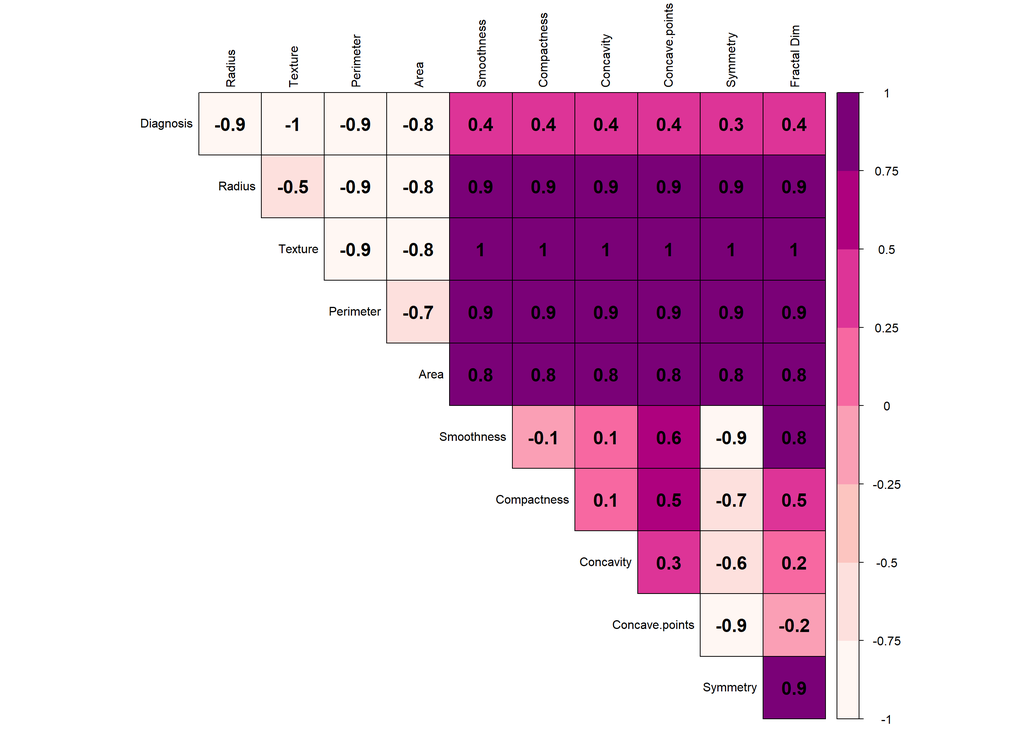

```r
#This makes a corrplot for the results of our corr matrix
corrplot(corr,
         method = "color",
         type = "upper",
         diag = FALSE,
         col = corrCol,
         outline = "black",
         addCoef.col = "black",
         number.cex = 1.5,
         number.digits = 1,
         tl.col = "black",
         cl.cex = 1,)
```

```r
#Model that includes all vars
allModel <- glm(diagnosis ~ radius_mean + texture_mean + perimeter_mean + area_mean + smoothness_mean + compactness_mean + concavity_mean + concave.points_mean + symmetry_mean + fractal_dimension_mean, data = mean_bc, family = "binomial")
#Model for Radius & Texture
trModel <- glm(diagnosis ~ radius_mean + texture_mean, data = mean_bc, family = "binomial")

#Models based off of Smoothness
s2cModel <- glm(diagnosis ~ smoothness_mean + compactness_mean + concavity_mean , data = mean_bc, family = "binomial")
scModel1 <- glm(diagnosis ~ smoothness_mean + concavity_mean, data = mean_bc, family = "binomial")
scModel2 <- glm(diagnosis ~ smoothness_mean + compactness_mean, data = mean_bc, family = "binomial")

#Models based off of Compactness
ccfModel <- glm(diagnosis ~ compactness_mean + concavity_mean + concave.points_mean + fractal_dimension_mean, data = mean_bc, family = "binomial")
ccfModel1 <- glm(diagnosis ~ compactness_mean + concavity_mean + concave.points_mean, data = mean_bc, family = "binomial")
ccfModel2 <- glm(diagnosis ~ compactness_mean + concavity_mean + fractal_dimension_mean, data = mean_bc, family = "binomial")
ccfModel3 <- glm(diagnosis ~ compactness_mean + concave.points_mean + fractal_dimension_mean, data = mean_bc, family = "binomial") #-------------
ccfModel4 <- glm(diagnosis ~ compactness_mean + concavity_mean, data = mean_bc, family = "binomial")
ccfModel5 <- glm(diagnosis ~ compactness_mean + concave.points_mean, data = mean_bc, family = "binomial")
ccfModel6 <- glm(diagnosis ~ compactness_mean + fractal_dimension_mean, data = mean_bc, family = "binomial")

#compactness_mean         concavity_mean fractal_dimension_mean
#Models based off of Concavity
cfModel <- glm(diagnosis ~ concavity_mean + concave.points_mean + fractal_dimension_mean, data = mean_bc, family = "binomial")
cfModel1 <- glm(diagnosis ~ concavity_mean + concave.points_mean, data = mean_bc, family = "binomial")
cfModel2 <- glm(diagnosis ~ concavity_mean + fractal_dimension_mean, data = mean_bc, family = "binomial")

#Model based off of Concave Points
cpfModel <- glm(diagnosis ~ concave.points_mean + fractal_dimension_mean, data = mean_bc, family = "binomial")

models <- list(allModel, trModel, s2cModel, scModel1, scModel2, ccfModel, ccfModel1, ccfModel2, ccfModel3, ccfModel4, ccfModel5, ccfModel6,
               cfModel, cfModel1, cfModel2, cpfModel)
```

Now we separate our data into training and testing sets. We set a seed in order to insure that whoever runs this program gets similar results.

```r
set.seed(42)
train.IDX <- sample(c(TRUE,FALSE), size = dim(mean_bc)[1], replace = TRUE, prob = c(.75,.25))
dataTrain <- mean_bc[train.IDX, ]
dataTest <- mean_bc[!train.IDX, ]
```

### Assumptions of Logistic Regression

Next we check to make sure the various assumptions of logistic regression are met. As a reminder they are:

- The response variable is binary
- The observations are independent
- There is no multicollinearity among your predictor variables (We did this already)
- There are no extreme values or extreme outliers
- There is a linear association between quantitative variables and the logit
- Large sample

```r
cat("Is it binary?\n",unique(mean_bc$diagnosis),
    "Yes\nAre the inputs independent?\n",length(unique(bc$id)) == length(bc$id),
    "Yes\nIs the sample is large enough?\n",dim(dataTrain)[1],"Yes")
```

```
## Is it binary?
##  1 0 Yes
## Are the inputs independent?
##  TRUE Yes
## Is the sample is large enough?
##  430 Yes
```

```r
unique(mean_bc$diagnosis)
```

```
## [1] 1 0
```

```r
length(unique(bc$id)) == length(bc$id)
```

```
## [1] TRUE
```

```r
dim(dataTrain)[1]
```

```
## [1] 430
```

```r
j=0
for (i in models) {
  j=j+1
  cat("Model",j,":\n")
  print(vif(i))
  cat("\n")
}
```

```
## Model 1 :
##            radius_mean           texture_mean         perimeter_mean
##             899.521292               1.806441             698.983071
##              area_mean        smoothness_mean       compactness_mean
##             129.559492               4.372939              15.280847
##         concavity_mean    concave.points_mean          symmetry_mean
##               5.259524               5.856371               1.839511
## fractal_dimension_mean
##               9.787700
##
## Model 2 :
##  radius_mean texture_mean
##      1.06525      1.06525
##
## Model 3 :
##  smoothness_mean compactness_mean   concavity_mean
##         1.540849         4.146115         3.229913
##
## Model 4 :
## smoothness_mean  concavity_mean
##        1.125685        1.125685
##
## Model 5 :
##  smoothness_mean compactness_mean
##         1.506242         1.506242
##
## Model 6 :
##       compactness_mean         concavity_mean    concave.points_mean
##               5.196916               3.262724               2.812120
## fractal_dimension_mean
##               3.926866
##
## Model 7 :
##    compactness_mean      concavity_mean concave.points_mean
##            3.140666            3.252144            2.585164
##
## Model 8 :
##       compactness_mean         concavity_mean fractal_dimension_mean
##               4.507340               2.635434               3.703524
##
```

[output cut: 16 more lines]

```
## Model 13 :
##         concavity_mean    concave.points_mean fractal_dimension_mean
##               3.284102               2.151006               2.175350
##
## Model 14 :
##      concavity_mean concave.points_mean
##            2.097797            2.097797
##
## Model 15 :
##         concavity_mean fractal_dimension_mean
##               1.981588               1.981588
##
## Model 16 :
##    concave.points_mean fractal_dimension_mean
##               1.372533               1.372533
```

```r
#Removing models that violate multicolinearity
models <- models[-c(1,6,9)]
```

```r
#Are there any extreme values? No
nParam <- 10
N <- dim(mean_bc)[1]
cutoff <- qf(0.5, df1 = nParam, df2 = N-nParam)

j=0
for (i in models) {
  cookD <- cooks.distance(i)
  print(sum(cookD > cutoff))
}
```

```
## [1] 0
## [1] 0
## [1] 0
## [1] 0
## [1] 0
## [1] 0
## [1] 0
## [1] 0
## [1] 0
## [1] 0
## [1] 0
## [1] 0
## [1] 0
```

```r
#Explanation of the more abstract function vars:
#predictor is the var to put in the x-axis
#label1 is the string to put in for the x-axis of the scatterplot
#colorNum is the index for the colorsT vector; Should be a num between 1 & 8

makeLogitPlots <- function(model, theData, predictor, label, colorNum){

  #Model
  probs <-  predict(model, data = theData, type = "response")
  logit<- log(probs/(1-probs))

  xLimit <- range(pretty(range(predictor)))
  yLimit <- range(pretty(range(logit)))

  #Graph 1
  plot(x=NULL, y=NULL, xlim = xLimit, ylim = yLimit, axes = FALSE, ann = FALSE)

  axis(1, at = pretty(xLimit), tck = -.015, lwd = 1, labels = FALSE)
  axis(2, at = pretty(yLimit), tck = -.015, lwd = 1, labels = FALSE)

  mtext(pretty(xLimit),1, line = .3, at = pretty(xLimit), las = 1, cex= .75)
  mtext(pretty(yLimit),2, line = .3, at = pretty(yLimit), las =1, cex= .75)

  mtext(label,1, font=2, line = 1.5)
  mtext("Logit",2, font=2 ,line=2)


  points(x = predictor, y = logit, col=colorsT[colorNum], pch = 19, cex = 3)
}
```

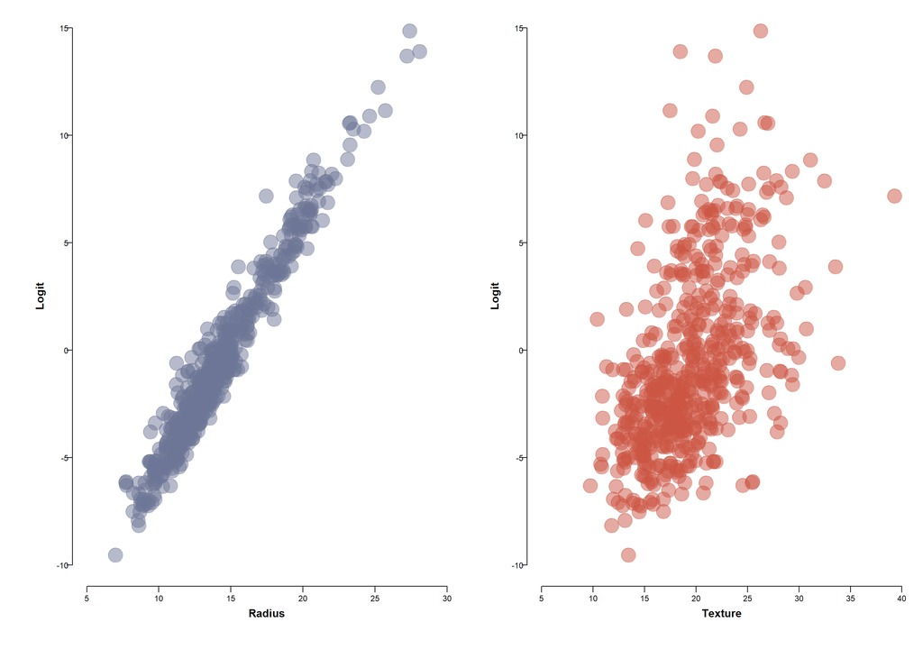

```r
############################################################################################
#Update mfrow with the correct dimensions
#I might need to make different functions and pars for the total amount of variables in each model

par(mfrow = c(1,2), mai = c(1,1,0,0), omi = c(.1,.1,.1,.1))

#Model 1
makeLogitPlots(trModel, mean_bc, mean_bc$radius_mean, "Radius", 1)
makeLogitPlots(trModel, mean_bc, mean_bc$texture_mean, "Texture", 2)
```

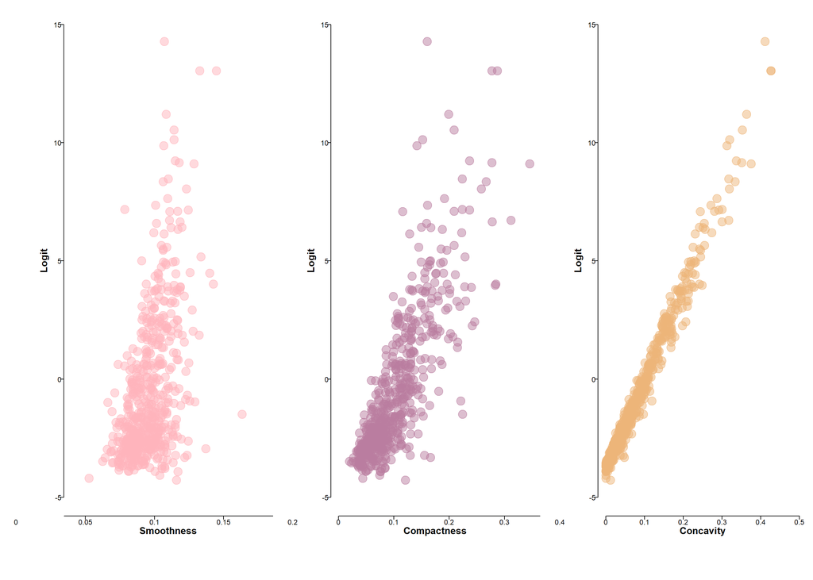

```r
#Model 2
par(mfrow = c(1,3), mai = c(1,1,0,0), omi = c(.1,.1,.1,.1))
makeLogitPlots(s2cModel, mean_bc, mean_bc$smoothness_mean, "Smoothness", 3)
makeLogitPlots(s2cModel, mean_bc, mean_bc$compactness_mean, "Compactness", 4)
makeLogitPlots(s2cModel, mean_bc, mean_bc$concavity_mean, "Concavity", 5)
```

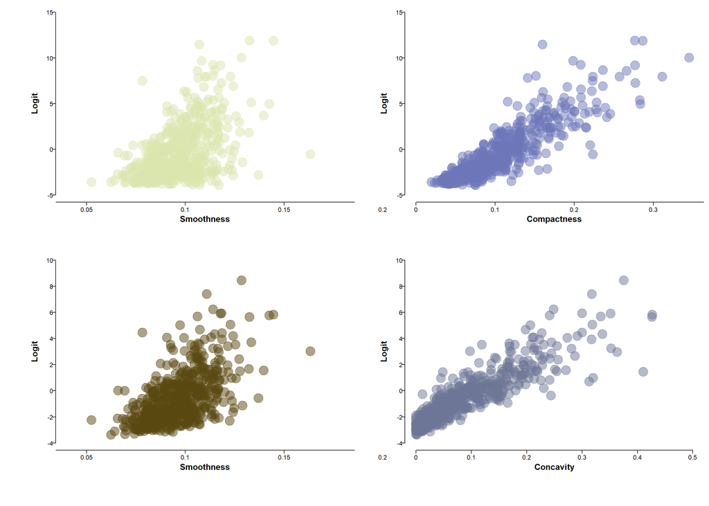

```r
#Model 3&4 --- Drop Model 3&4
par(mfrow = c(2,2), mai = c(1,1,0,0), omi = c(.1,.1,.1,.1))
makeLogitPlots(scModel1, mean_bc, mean_bc$smoothness_mean, "Smoothness", 6)
makeLogitPlots(scModel1, mean_bc, mean_bc$compactness_mean, "Compactness", 7)
#---
makeLogitPlots(scModel2, mean_bc, mean_bc$smoothness_mean, "Smoothness", 8)
makeLogitPlots(scModel2, mean_bc, mean_bc$concavity_mean, "Concavity", 1)
```

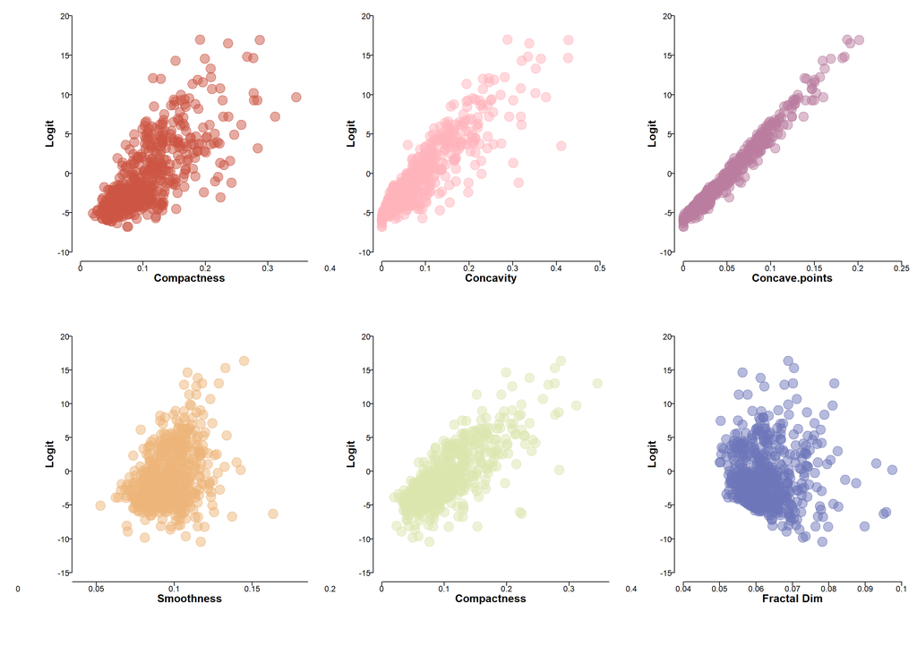

```r
#Model 5&6 --- Drop model 6
par(mfrow = c(2,3), mai = c(1,1,0,0), omi = c(.1,.1,.1,.1))
makeLogitPlots(ccfModel1, mean_bc, mean_bc$compactness_mean, "Compactness", 2)
makeLogitPlots(ccfModel1, mean_bc, mean_bc$concavity_mean, "Concavity", 3)
makeLogitPlots(ccfModel1, mean_bc, mean_bc$concave.points_mean, "Concave.points", 4)
#---
makeLogitPlots(ccfModel2, mean_bc, mean_bc$smoothness_mean, "Smoothness", 5)
makeLogitPlots(ccfModel2, mean_bc, mean_bc$compactness_mean, "Compactness", 6)
makeLogitPlots(ccfModel2, mean_bc, mean_bc$fractal_dimension_mean, "Fractal Dim", 7)
```

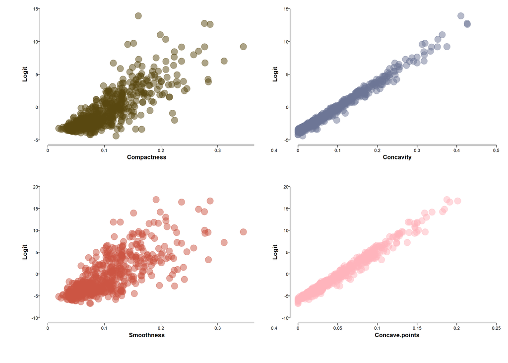

```r
#Model 7&8
par(mfrow = c(2,2), mai = c(1,1,0,0), omi = c(.1,.1,.1,.1))
makeLogitPlots(ccfModel4, mean_bc, mean_bc$compactness_mean, "Compactness", 8)
makeLogitPlots(ccfModel4, mean_bc, mean_bc$concavity_mean, "Concavity", 1)
#---
makeLogitPlots(ccfModel5, mean_bc, mean_bc$compactness_mean, "Smoothness", 2)
makeLogitPlots(ccfModel5, mean_bc, mean_bc$concave.points_mean, "Concave.points", 3)
```

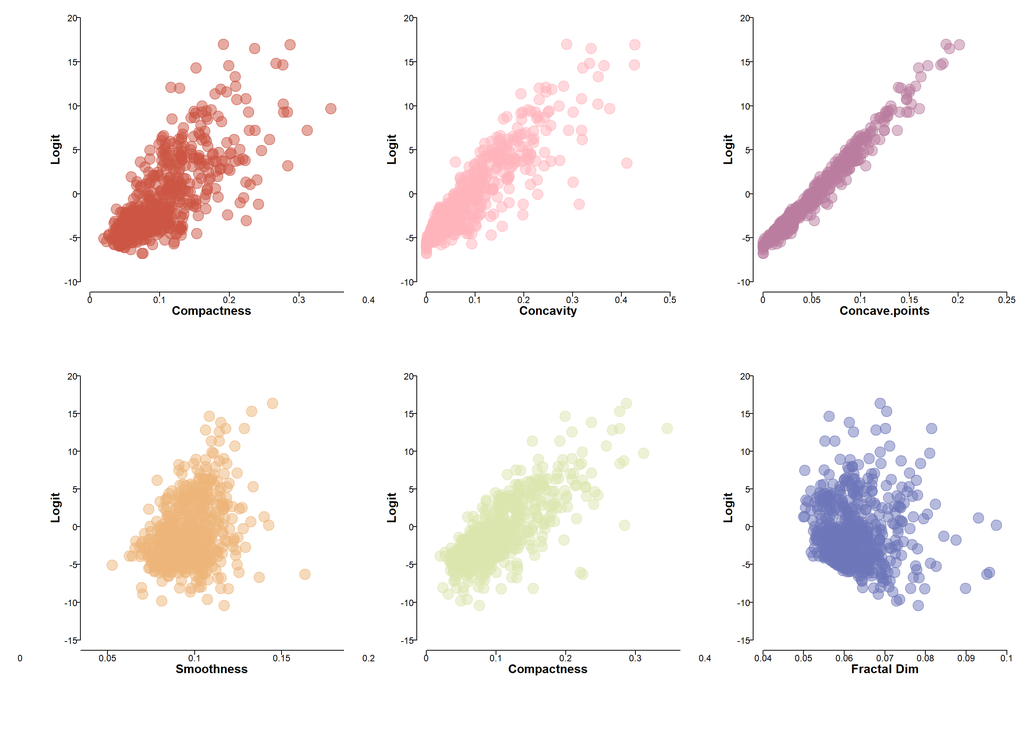

```r
#Model 9&10 --- Drop 10
par(mfrow = c(2,3), mai = c(1,1,0,0), omi = c(.1,.1,.1,.1))
makeLogitPlots(ccfModel1, mean_bc, mean_bc$compactness_mean, "Compactness", 2)
makeLogitPlots(ccfModel1, mean_bc, mean_bc$concavity_mean, "Concavity", 3)
makeLogitPlots(ccfModel1, mean_bc, mean_bc$concave.points_mean, "Concave.points", 4)
#---
makeLogitPlots(ccfModel2, mean_bc, mean_bc$smoothness_mean, "Smoothness", 5)
makeLogitPlots(ccfModel2, mean_bc, mean_bc$compactness_mean, "Compactness", 6)
makeLogitPlots(ccfModel2, mean_bc, mean_bc$fractal_dimension_mean, "Fractal Dim", 7)
```

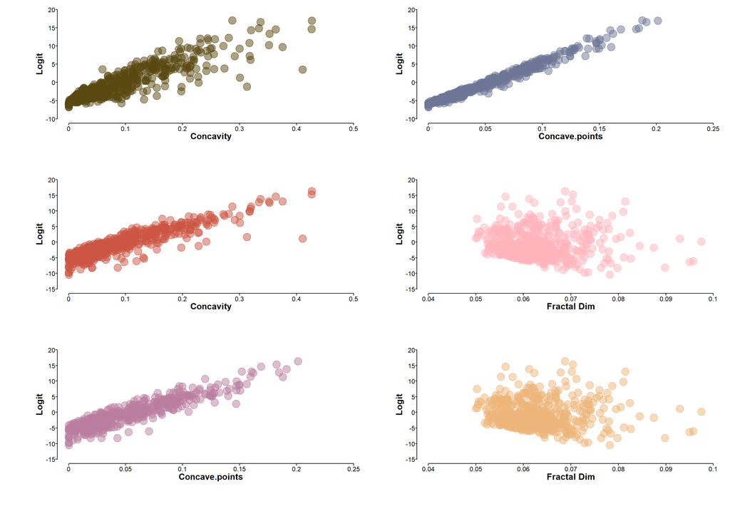

```r
#Model 11,12&13 --- Drop 12 & 13
par(mfrow = c(3,2), mai = c(1,1,0,0), omi = c(.1,.1,.1,.1))
makeLogitPlots(ccfModel1, mean_bc, mean_bc$concavity_mean, "Concavity", 8)
makeLogitPlots(ccfModel1, mean_bc, mean_bc$concave.points_mean, "Concave.points", 1)
#---
makeLogitPlots(ccfModel2, mean_bc, mean_bc$concavity_mean, "Concavity", 2)
makeLogitPlots(ccfModel2, mean_bc, mean_bc$fractal_dimension_mean, "Fractal Dim", 3)
#---
makeLogitPlots(ccfModel2, mean_bc, mean_bc$concave.points_mean, "Concave.points", 4)
makeLogitPlots(ccfModel2, mean_bc, mean_bc$fractal_dimension_mean, "Fractal Dim", 5)
```

```r
############################################################################################

#Drops models we believe violate logit association
models <- models[-c(3,4,6,10,12,13)]
```

```r
lapply(models, vif)
```

```
## [[1]]
##  radius_mean texture_mean
##      1.06525      1.06525
##
## [[2]]
##  smoothness_mean compactness_mean   concavity_mean
##         1.540849         4.146115         3.229913
##
## [[3]]
##    compactness_mean      concavity_mean concave.points_mean
##            3.140666            3.252144            2.585164
##
## [[4]]
## compactness_mean   concavity_mean
##         3.047688         3.047688
##
## [[5]]
##    compactness_mean concave.points_mean
##             2.19551             2.19551
##
## [[6]]
##       compactness_mean fractal_dimension_mean
##               3.347431               3.347431
##
## [[7]]
##      concavity_mean concave.points_mean
##            2.097797            2.097797
```

### Results of Models

```r
j=0
modelPerf <- matrix( ,nrow = length(models), ncol = 4)
predicts <- matrix( ,nrow = dim(dataTest)[1], ncol = length(models))
predictDF <- data.frame(predicts)

for(i in models){
  j=j+1
  yPred <- predict(i, newdata = dataTest, type = "response")
  dataTest$Predict <- yPred > 0.5
  predictDF[,j] <- dataTest$Predict

  accuracy <- sum(dataTest$Predict == dataTest$diagnosis)/length(dataTest$diagnosis)
  falsePos <- sum(dataTest$Predict == 1 & dataTest$diagnosis == 0)/sum(dataTest$diagnosis == 1)
  falseNeg <- sum(dataTest$Predict == 0 & dataTest$diagnosis == 1)/sum(dataTest$diagnosis == 0)
  posPredict <-  sum(dataTest$Predict == TRUE & dataTest$diagnosis == 1) / sum(dataTest$Predict == TRUE)
  temp <- c(accuracy, falsePos, falseNeg, posPredict)

  for (k in 1:length(temp)) {
    modelPerf[j,k] <- temp[k]
  }
  cat("\n\nModel",j,"\nAccuracy:\n",(100*round(accuracy,3)),"%",
      "\nFalse Positive Rate:\n",(100*round(falsePos,3)),"%",
      "\nFalse Negative Rate:\n",(100*round(falseNeg,3)),"%",
      "\nPositive Predict Rate:\n", (100*round(posPredict,3)),"%")
  temp <- temp[-c(1:4)]
}
```

```
##
##
## Model 1
## Accuracy:
##  85.6 %
## False Positive Rate:
##  18.8 %
## False Negative Rate:
##  12.1 %
## Positive Predict Rate:
##  80.4 %
##
## Model 2
## Accuracy:
##  84.2 %
## False Positive Rate:
##  16.7 %
## False Negative Rate:
##  15.4 %
## Positive Predict Rate:
##  81 %
##
## Model 3
## Accuracy:
##  90.6 %
## False Positive Rate:
##  12.5 %
## False Negative Rate:
##  7.7 %
## Positive Predict Rate:
##  87.2 %
##
## Model 4
## Accuracy:
##  84.2 %
## False Positive Rate:
##  16.7 %
## False Negative Rate:
##  15.4 %
## Positive Predict Rate:
```

[output cut: 16 more lines]

```
##  22.9 %
## False Negative Rate:
##  11 %
## Positive Predict Rate:
##  77.6 %
##
## Model 7
## Accuracy:
##  87.1 %
## False Positive Rate:
##  20.8 %
## False Negative Rate:
##  8.8 %
## Positive Predict Rate:
##  80 %
```

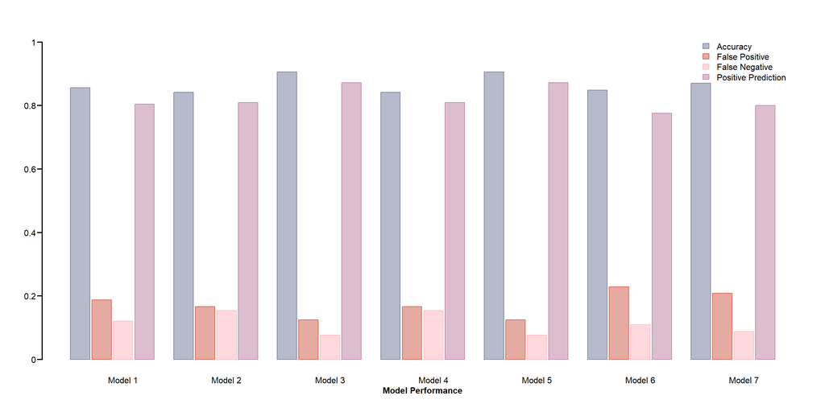

```r
modelNames <- c("Model 1","Model 2","Model 3", "Model 4","Model 5","Model 6","Model 7")
xpos<- barplot(t(modelPerf) ,
        space = c(0.1,1),
        beside = TRUE,
        axes = FALSE,
        ylim = c(0,1),
        col = colorsT[0:4],
        border = colors[0:4])

axis(2, at = pretty(c(0,1)), tck = -.015, lwd = 2, labels = FALSE)
mtext(pretty(c(0,1)), 2, at = pretty(c(0,1)), line = .6, las = 1)

mtext("Model Performance", 1.5, font = 2, line = 2.5)
mtext(modelNames, 1, at = xpos[3,],line = 1.5)

legend(33,1.02, legend = c("Accuracy","False Positive","False Negative","Positive Prediction"), fill = colorsT[0:4], border = colors[0:4], bty = "n")
```

```r
predictDF$Diagnosis <- dataTest$diagnosis

predictM <- matrix(,nrow = 8, ncol = 2)

predictM[1,1] <- sum(predictDF$Diagnosis == 1)/length(predictDF$Diagnosis)
predictM[1,2] <- sum(predictDF$Diagnosis == 0)/length(predictDF$Diagnosis)

predictM[2,1] <- sum(predictDF$X1 == TRUE)/length(predictDF$X1)
predictM[2,2] <- sum(predictDF$X1 == FALSE)/length(predictDF$X1)

predictM[3,1] <- sum(predictDF$X2 == TRUE)/length(predictDF$X3)
predictM[3,2] <- sum(predictDF$X2 == FALSE)/length(predictDF$X3)

predictM[4,1] <- sum(predictDF$X3 == TRUE)/length(predictDF$X3)
predictM[4,2] <- sum(predictDF$X3 == FALSE)/length(predictDF$X3)

predictM[5,1] <- sum(predictDF$X4 == TRUE)/length(predictDF$X4)
predictM[5,2] <- sum(predictDF$X4 == FALSE)/length(predictDF$X4)

predictM[6,1] <- sum(predictDF$X5 == TRUE)/length(predictDF$X5)
predictM[6,2] <- sum(predictDF$X5 == FALSE)/length(predictDF$X5)

predictM[7,1] <- sum(predictDF$X6 == TRUE)/length(predictDF$X6)
predictM[7,2] <- sum(predictDF$X6 == FALSE)/length(predictDF$X6)

predictM[8,1] <- sum(predictDF$X7 == TRUE)/length(predictDF$X6)
predictM[8,2] <- sum(predictDF$X7 == FALSE)/length(predictDF$X6)
```

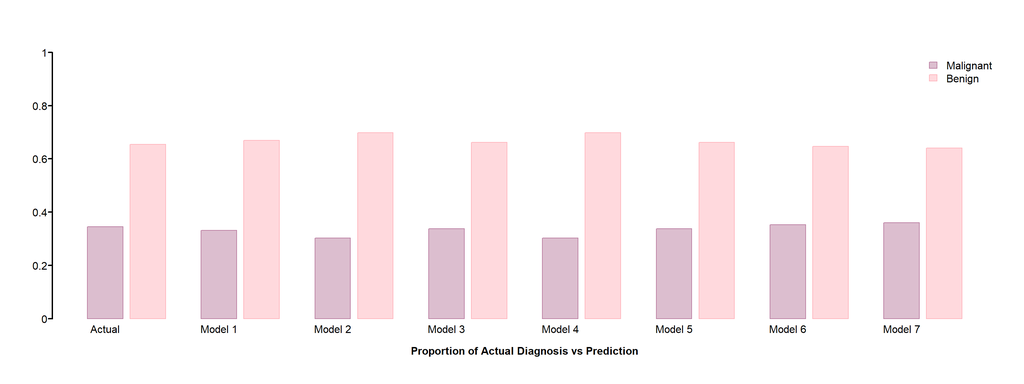

```r
xpos<- barplot( t(predictM),
        space = c(0.2,1),
        beside = TRUE,
        axes = FALSE,
        ylim = c(0,1),
        col = colorsT[c(4,3)],
        border = colors[c(4,3)])

axis(2, at = pretty(c(0,1)), tck = -.015, lwd = 2, labels = FALSE)
mtext(abs(pretty(c(0,1))), 2, at = pretty(c(0,1)), line = .4, las = 1)

mtext("Proportion of Actual Diagnosis vs Prediction", 1.5, font = 2, line = 2)
mtext(c("Actual",modelNames), 1, at = xpos[1,], line = .3)

legend("topright", legend = c("Malignant","Benign"), fill = c(colorsT[4], colorsT[3]), border = colors[c(4, 3)], bty = "n")
```

```r
for (i in models) {
  print(summary(i))
}
```

```
##
## Call:
## glm(formula = diagnosis ~ radius_mean + texture_mean, family = "binomial",
##     data = mean_bc)
##
## Deviance Residuals:
##     Min       1Q   Median       3Q      Max
## -2.1460  -0.3794  -0.1205   0.1267   2.8449
##
## Coefficients:
##               Estimate Std. Error z value Pr(>|z|)
## (Intercept)  -19.84942    1.77395 -11.189  < 2e-16 ***
## radius_mean    1.05710    0.10148  10.417  < 2e-16 ***
## texture_mean   0.21814    0.03707   5.885 3.98e-09 ***
## ---
## Signif. codes:  0 '***' 0.001 '**' 0.01 '*' 0.05 '.' 0.1 ' ' 1
##
## (Dispersion parameter for binomial family taken to be 1)
##
##     Null deviance: 751.44  on 568  degrees of freedom
## Residual deviance: 291.12  on 566  degrees of freedom
## AIC: 297.12
##
## Number of Fisher Scoring iterations: 7
##
##
## Call:
## glm(formula = diagnosis ~ smoothness_mean + compactness_mean +
##     concavity_mean, family = "binomial", data = mean_bc)
##
## Deviance Residuals:
##     Min       1Q   Median       3Q      Max
## -5.3455  -0.4729  -0.2876   0.2912   2.3457
##
## Coefficients:
##                  Estimate Std. Error z value Pr(>|z|)
## (Intercept)        -4.085      1.047  -3.900 9.61e-05 ***
## smoothness_mean    14.600     12.935   1.129  0.25903
## compactness_mean  -20.294      7.170  -2.830  0.00465 **
## concavity_mean     48.811      5.465   8.931  < 2e-16 ***
```

[output cut: 121 more lines]

```
## Coefficients:
##                     Estimate Std. Error z value Pr(>|z|)
## (Intercept)          -5.9134     0.4889 -12.096   <2e-16 ***
## concavity_mean       -6.9898     4.4865  -1.558    0.119
## concave.points_mean 120.8767    13.2360   9.132   <2e-16 ***
## ---
## Signif. codes:  0 '***' 0.001 '**' 0.01 '*' 0.05 '.' 0.1 ' ' 1
##
## (Dispersion parameter for binomial family taken to be 1)
##
##     Null deviance: 751.44  on 568  degrees of freedom
## Residual deviance: 256.58  on 566  degrees of freedom
## AIC: 262.58
##
## Number of Fisher Scoring iterations: 7
```